# Exploration of NOAA Storm Data

Author: Dino Chioda

Date: May 23, 2015

## Synopsis

Storms and other severe weather events can cause both public health and economic problems for communities and municipalities. Many severe events can result in fatalities, injuries, and property damage, and preventing such outcomes to the extent possible is a key concern.

The Storm Events Database of the National Oceanic and Atmospheric Administration (NOAA) tracks characteristics of major storms and weather events in the United States, including when and where they occur, as well as estimates of any fatalities, injuries, and property damage. The events in the database start in the year 1950 and end in November 2011 - the data is more complete in more recent years as the quality of the records improved.

This report will delve into this data and answer some basic questions about severe weather events with the ultimate goal of providing guidelines to prioritize resources for different types of events.

## Data Processing

### Downloading the data

The data for this report was downloaded from the [National Oceanic and Atmospheric Administration](http://www.nws.noaa.gov) storm database. The data can be downloaded by clicking [here](https://d396qusza40orc.cloudfront.net/repdata%2Fdata%2FStormData.csv.bz2). It is a zipped CSV file and will need to be unzipped to be loaded into a dataset.

```r
url <- "https://d396qusza40orc.cloudfront.net/repdata%2Fdata%2FStormData.csv.bz2"

# Download the file (if needed)
if (!file.exists("/Users/Dino/Documents/git/repro_research/PA2/storm.csv.bz2")) {
    download.file(url, "/Users/Dino/Documents/git/repro_research/PA2/storm.csv.bz2", method="curl")
}
# Unzip the file (if needed)
if (!file.exists("/Users/Dino/Documents/git/repro_research/PA2/storm.csv")) {
    library(R.utils)
    bunzip2("/Users/Dino/Documents/git/repro_research/PA2/storm.csv.bz2", "/Users/Dino/Documents/git/repro_research/PA2/storm.csv", remove = FALSE)
}
```

### Loading and prepping the data

The following actions will be taken to make the data more readable and usable:

1. Assign some column names to make the data more usable.
2. Clean up the exponential data in CROPDMGEXP and PROPDMGEXP and use it to calculate the correct amount of crop and property damage.

```r
# Load data into R
storm_raw <- read.csv("/Users/Dino/Documents/git/repro_research/PA2/storm.csv")
storm <- storm_raw[c("EVTYPE", "FATALITIES","INJURIES", "PROPDMG", "PROPDMGEXP","CROPDMG", "CROPDMGEXP")]

#Find unique crop damage exponential values
unique(storm$CROPDMGEXP)
```

```
## [1]   M K m B ? 0 k 2
## Levels:  ? 0 2 B k K m M
```

```r
# Clean crop exponential data
storm$CROPEXP[storm$CROPDMGEXP == "M"] <- 1000000
storm$CROPEXP[storm$CROPDMGEXP == "K"] <- 1000
storm$CROPEXP[storm$CROPDMGEXP == "m"] <- 1000000
storm$CROPEXP[storm$CROPDMGEXP == "B"] <- 1000000000
storm$CROPEXP[storm$CROPDMGEXP == "0"] <- 1
storm$CROPEXP[storm$CROPDMGEXP == "k"] <- 1000
storm$CROPEXP[storm$CROPDMGEXP == "2"] <- 100
storm$CROPEXP[storm$CROPDMGEXP == ""] <- 1
storm$CROPEXP[storm$CROPDMGEXP == "?"] <- 0

#Find unique property damage exponential values
unique(storm$PROPDMGEXP)
```

```
##  [1] K M   B m + 0 5 6 ? 4 2 3 h 7 H - 1 8
## Levels:  - ? + 0 1 2 3 4 5 6 7 8 B h H K m M
```

```r
# Clean property exponential data
storm$PROPEXP[storm$PROPDMGEXP == "K"] <- 1000
storm$PROPEXP[storm$PROPDMGEXP == "M"] <- 1000000
storm$PROPEXP[storm$PROPDMGEXP == ""] <- 1
storm$PROPEXP[storm$PROPDMGEXP == "B"] <- 10000000000
storm$PROPEXP[storm$PROPDMGEXP == "m"] <- 1000000
storm$PROPEXP[storm$PROPDMGEXP == "0"] <- 1
storm$PROPEXP[storm$PROPDMGEXP == "5"] <- 100000
storm$PROPEXP[storm$PROPDMGEXP == "6"] <- 1000000
storm$PROPEXP[storm$PROPDMGEXP == "4"] <- 10000
storm$PROPEXP[storm$PROPDMGEXP == "2"] <- 100
storm$PROPEXP[storm$PROPDMGEXP == "3"] <- 1000
storm$PROPEXP[storm$PROPDMGEXP == "h"] <- 100
storm$PROPEXP[storm$PROPDMGEXP == "7"] <- 10000000
storm$PROPEXP[storm$PROPDMGEXP == "H"] <- 100
storm$PROPEXP[storm$PROPDMGEXP == "1"] <- 10
storm$PROPEXP[storm$PROPDMGEXP == "8"] <- 100000000
storm$PROPEXP[storm$PROPDMGEXP == "+"] <- 0
storm$PROPEXP[storm$PROPDMGEXP == "-"] <- 0
storm$PROPEXP[storm$PROPDMGEXP == "?"] <- 0

# Calculate correct dollar values for property and crop damage
storm$CROPDMG <- storm$CROPDMG * storm$CROPEXP / 1000000000
storm$PROPDMG <- storm$PROPDMG * storm$PROPEXP / 1000000000
storm <- storm[,c("EVTYPE","FATALITIES","INJURIES","PROPDMG", "CROPDMG")]
```

## Results

### Assessing effects of Meteorological Events on Population Health

We can consider the term harmful as meaning that there occurred either a **fatality** or an **injury** to a person. Therefore, let us create two subsets of data from these perspectives:

```r
fatalities <- aggregate(FATALITIES ~ EVTYPE, storm, sum)
fatalities <- fatalities[order(-fatalities$FATALITIES),][1:10,]
head(fatalities)
```

```
##             EVTYPE FATALITIES
## 834        TORNADO       5633
## 130 EXCESSIVE HEAT       1903
## 153    FLASH FLOOD        978
## 275           HEAT        937
## 464      LIGHTNING        816
## 856      TSTM WIND        504
```

```r
injuries <- aggregate(INJURIES ~ EVTYPE, storm, sum)
injuries <- injuries[order(-injuries$INJURIES),][1:10,]
head(injuries)
```

```
##             EVTYPE INJURIES
## 834        TORNADO    91346
## 856      TSTM WIND     6957
## 170          FLOOD     6789
## 130 EXCESSIVE HEAT     6525
## 464      LIGHTNING     5230
## 275           HEAT     2100
```

Let’s now plot these two datasets:

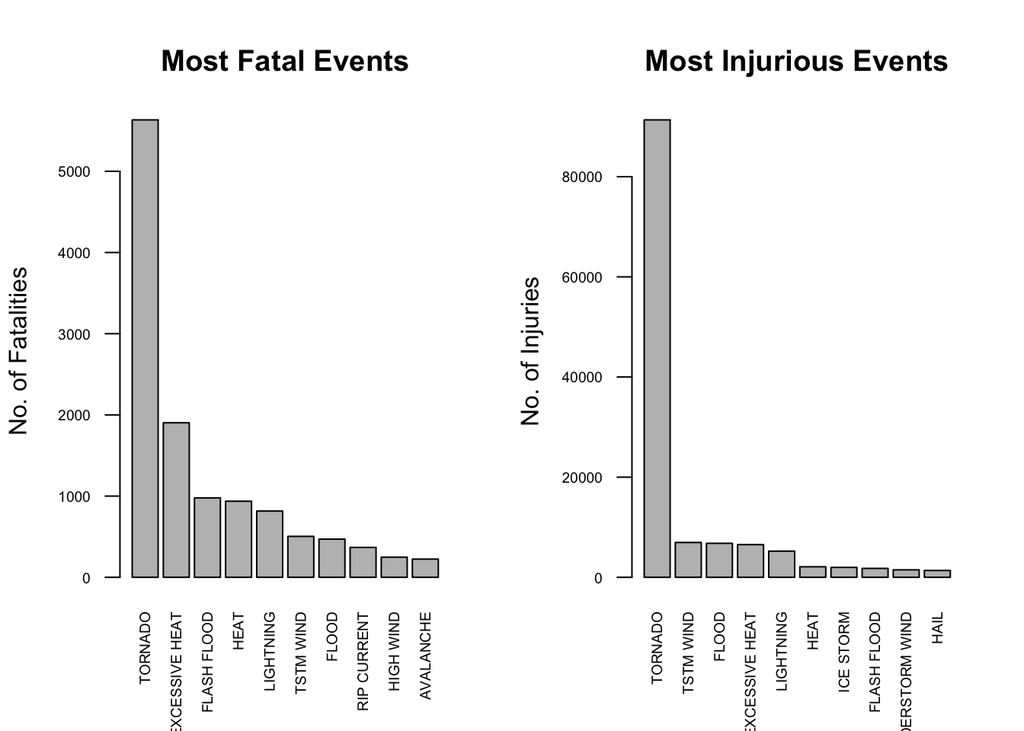

```r
par(mfrow = c(1, 2))
barplot(fatalities$FATALITIES, names.arg = fatalities$EVTYPE, main= "Most Fatal Events", ylab = "No. of Fatalities", las = 2, cex.names = 0.6, cex.axis = 0.6)
barplot(injuries$INJURIES, names.arg = injuries$EVTYPE, main= "Most Injurious Events", ylab = "No. of Injuries", las = 2, cex.names = 0.6, cex.axis = 0.6)
```

The event type that inflicts the most fatalities to the population is **TORNADO**. The event type that inflicts the most injuries to the population is **TORNADO**.

### Assessing effects of Meteorological Events on Property and Crop Values

Let us use the same approach as we used for population health and subset the data into **crop damage** and **property damage**.

```r
crop_dmg <- aggregate(CROPDMG ~ EVTYPE, storm, sum)
crop_dmg <- crop_dmg[order(-crop_dmg$CROPDMG),][1:10,]
head(crop_dmg)
```

```
##          EVTYPE   CROPDMG
## 95      DROUGHT 13.972566
## 170       FLOOD  5.661968
## 590 RIVER FLOOD  5.029459
## 427   ICE STORM  5.022113
## 244        HAIL  3.025954
## 402   HURRICANE  2.741910
```

```r
prop_dmg <- aggregate(PROPDMG ~ EVTYPE, storm, sum)
prop_dmg <- prop_dmg[order(-prop_dmg$PROPDMG),][1:10,]
head(prop_dmg)
```

```
##                EVTYPE    PROPDMG
## 170             FLOOD 1247.15771
## 411 HURRICANE/TYPHOON  658.80584
## 670       STORM SURGE  426.36354
## 834           TORNADO  104.64738
## 402         HURRICANE   63.16832
## 848    TROPICAL STORM   54.05389
```

Let’s now plot these datasets in a barplot:

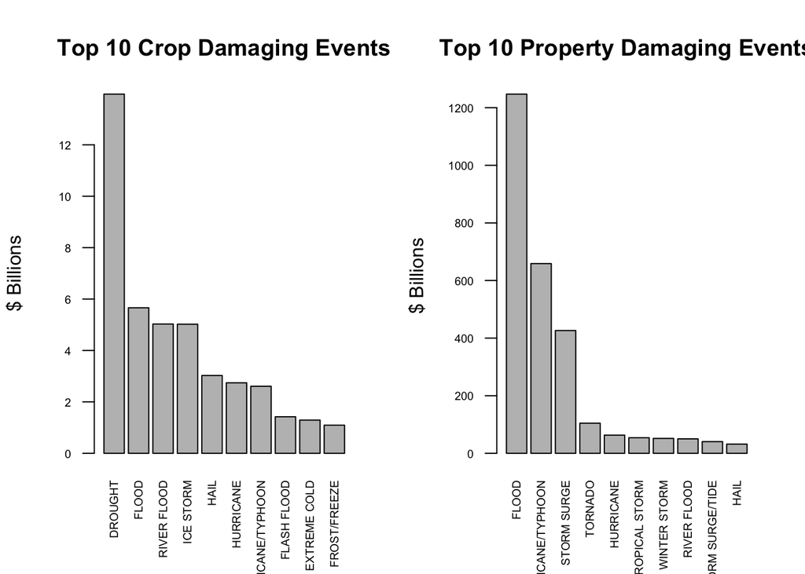

```r
par(mfrow = c(1, 2))
barplot(crop_dmg$CROPDMG, names.arg = crop_dmg$EVTYPE, main= "Top 10 Crop Damaging Events", ylab = " $ Billions", las = 2, cex.names = 0.6, cex.axis = 0.6)
barplot(prop_dmg$PROPDMG, names.arg = prop_dmg$EVTYPE, main= "Top 10 Property Damaging Events", ylab = "$ Billions", las = 2, cex.names = 0.6, cex.axis = 0.6)
```

The event type that inflicts the most crop damage to is **DROUGHT**. The event type that inflicts the most property damage is **FLOOD**.